# DATA SCIENCE SESSIONS VOL. 3

### A Foundational Python Data Science Course

## Session 02: Fundamental Data Structures and Classes. Subsetting a Pandas DataFrame.

[← Back to course webpage](https://datakolektiv.com/)

Feedback should be send to goran.milovanovic@datakolektiv.com.

These notebooks accompany the DATA SCIENCE SESSIONS VOL. 3 :: A Foundational Python Data Science Course.

[figure not shown]

### Lecturers

[Goran S. Milovanović, PhD, DataKolektiv, Chief Scientist & Owner](https://www.linkedin.com/in/gmilovanovic/)

[Aleksandar Cvetković, PhD, DataKolektiv, Consultant](https://www.linkedin.com/in/alegzndr/)

[Ilija Lazarević, MA, DataKolektiv, Consultant](https://www.linkedin.com/in/ilijalazarevic/)

[figure not shown]

### 0. What do we want to do today?

Our goal in **Session02** is to learn more about the relationship between the fundamental data structures (lists and dictionaries, in the first place) and the Pandas DataFrame class. We will also focus on elementary subsetting of a Pandas DataFrame and learn to work with this important class. We will further explores lists and dictionaries along the way. Our goal is to prepare ourselves to start working with data in Python efficiently as of the next week.

**Prerequisits.** None. There is a Python console open in front of your eyes and you can reach your machine’s keyboard.

#### 1. Where am I?

Your are (or you should be...) in the `session02` directory, where we find

- this notebook,
- it's HTML version,
- another directory: `_data`
- and a `.csv` file named `BostonHousingData.csv` in it.

**NOTE.** `csv.` files play a prominent role in Data Science. If you do not know what a `.csv` (Comma Separated Values) file is, read through this document:[What Is a CSV File, and How Do I Open It? - by Chris Hoffman, Editor-in-Chief, How-To Geek](https://www.howtogeek.com/348960/what-is-a-csv-file-and-how-do-i-open-it/).

The Boston Housing Data Set is available from GitHub [here](https://raw.githubusercontent.com/selva86/datasets/master/BostonHousing.csv).

```python
import os
work_dir = os.getcwd()
print(work_dir)
print(os.listdir(work_dir))
data_dir = os.path.join(work_dir, "_data")
print(os.listdir(data_dir))
```

```
/home/ikacikac/workspace/dss03python2023/session02
['tasklist02_solutions.ipynb', 'dss03_py_session02.html', 'tasklist02_solutions.html', 'tasklist02.ipynb', '.ipynb_checkpoints', 'dss03_py_session02.ipynb', '_data']
['BostonHousingData.csv', 'MovieRatings.csv']
```

`BostonHousingData.csv` is a data set, in a CSV format, that we will next load into a Pandas DataFrame in order to study it. It is also one of the data sets that were frequently used to benchmark Machine Learning algorithms in the past.

The data was originally published by Harrison, D. and Rubinfeld, D.L. Hedonic prices and the demand for clean air, *J. Environ. Economics & Management*, vol.5, 81-102, 1978.

### 2. Pandas `DataFrame` class: let's see what we have here.

Import Pandas:

```python
import pandas as pd
```

First we need to load `BostonHousingData.csv` into a Pandas DataFrame.

```python
filename = 'BostonHousingData.csv'
data_set = pd.read_csv(os.path.join(data_dir, filename))
```

Let's take a look at `data_set` now:

```python
display(data_set)
```

|  | crim | zn | indus | chas | nox | rm | age | dis | rad | tax | ptratio | b | lstat | medv |
| --- | --- | --- | --- | --- | --- | --- | --- | --- | --- | --- | --- | --- | --- | --- |
| 0 | 0.00632 | 18.0 | 2.31 | 0 | 0.538 | 6.575 | 65.2 | 4.0900 | 1 | 296 | 15.3 | 396.90 | 4.98 | 24.0 |
| 1 | 0.02731 | 0.0 | 7.07 | 0 | 0.469 | 6.421 | 78.9 | 4.9671 | 2 | 242 | 17.8 | 396.90 | 9.14 | 21.6 |
| 2 | 0.02729 | 0.0 | 7.07 | 0 | 0.469 | 7.185 | 61.1 | 4.9671 | 2 | 242 | 17.8 | 392.83 | 4.03 | 34.7 |
| 3 | 0.03237 | 0.0 | 2.18 | 0 | 0.458 | 6.998 | 45.8 | 6.0622 | 3 | 222 | 18.7 | 394.63 | 2.94 | 33.4 |
| 4 | 0.06905 | 0.0 | 2.18 | 0 | 0.458 | 7.147 | 54.2 | 6.0622 | 3 | 222 | 18.7 | 396.90 | 5.33 | 36.2 |
| ... | ... | ... | ... | ... | ... | ... | ... | ... | ... | ... | ... | ... | ... | ... |
| 501 | 0.06263 | 0.0 | 11.93 | 0 | 0.573 | 6.593 | 69.1 | 2.4786 | 1 | 273 | 21.0 | 391.99 | 9.67 | 22.4 |
| 502 | 0.04527 | 0.0 | 11.93 | 0 | 0.573 | 6.120 | 76.7 | 2.2875 | 1 | 273 | 21.0 | 396.90 | 9.08 | 20.6 |
| 503 | 0.06076 | 0.0 | 11.93 | 0 | 0.573 | 6.976 | 91.0 | 2.1675 | 1 | 273 | 21.0 | 396.90 | 5.64 | 23.9 |
| 504 | 0.10959 | 0.0 | 11.93 | 0 | 0.573 | 6.794 | 89.3 | 2.3889 | 1 | 273 | 21.0 | 393.45 | 6.48 | 22.0 |
| 505 | 0.04741 | 0.0 | 11.93 | 0 | 0.573 | 6.030 | 80.8 | 2.5050 | 1 | 273 | 21.0 | 396.90 | 7.88 | 11.9 |

506 rows × 14 columns

We could have also used `print()` but `display()` from the `IPython.display` module is better...

```python
print(data_set)
```

```
        crim    zn  indus  chas    nox     rm   age     dis  rad  tax  \
0    0.00632  18.0   2.31     0  0.538  6.575  65.2  4.0900    1  296
1    0.02731   0.0   7.07     0  0.469  6.421  78.9  4.9671    2  242
2    0.02729   0.0   7.07     0  0.469  7.185  61.1  4.9671    2  242
3    0.03237   0.0   2.18     0  0.458  6.998  45.8  6.0622    3  222
4    0.06905   0.0   2.18     0  0.458  7.147  54.2  6.0622    3  222
..       ...   ...    ...   ...    ...    ...   ...     ...  ...  ...
501  0.06263   0.0  11.93     0  0.573  6.593  69.1  2.4786    1  273
502  0.04527   0.0  11.93     0  0.573  6.120  76.7  2.2875    1  273
503  0.06076   0.0  11.93     0  0.573  6.976  91.0  2.1675    1  273
504  0.10959   0.0  11.93     0  0.573  6.794  89.3  2.3889    1  273
505  0.04741   0.0  11.93     0  0.573  6.030  80.8  2.5050    1  273

     ptratio       b  lstat  medv
0       15.3  396.90   4.98  24.0
1       17.8  396.90   9.14  21.6
2       17.8  392.83   4.03  34.7
3       18.7  394.63   2.94  33.4
4       18.7  396.90   5.33  36.2
..       ...     ...    ...   ...
501     21.0  391.99   9.67  22.4
502     21.0  396.90   9.08  20.6
503     21.0  396.90   5.64  23.9
504     21.0  393.45   6.48  22.0
505     21.0  396.90   7.88  11.9

[506 rows x 14 columns]
```

Take a look at the first ten rows of `data_set`:

```python
data_set.head(10)
```

|  | crim | zn | indus | chas | nox | rm | age | dis | rad | tax | ptratio | b | lstat | medv |
| --- | --- | --- | --- | --- | --- | --- | --- | --- | --- | --- | --- | --- | --- | --- |
| 0 | 0.00632 | 18.0 | 2.31 | 0 | 0.538 | 6.575 | 65.2 | 4.0900 | 1 | 296 | 15.3 | 396.90 | 4.98 | 24.0 |
| 1 | 0.02731 | 0.0 | 7.07 | 0 | 0.469 | 6.421 | 78.9 | 4.9671 | 2 | 242 | 17.8 | 396.90 | 9.14 | 21.6 |
| 2 | 0.02729 | 0.0 | 7.07 | 0 | 0.469 | 7.185 | 61.1 | 4.9671 | 2 | 242 | 17.8 | 392.83 | 4.03 | 34.7 |
| 3 | 0.03237 | 0.0 | 2.18 | 0 | 0.458 | 6.998 | 45.8 | 6.0622 | 3 | 222 | 18.7 | 394.63 | 2.94 | 33.4 |
| 4 | 0.06905 | 0.0 | 2.18 | 0 | 0.458 | 7.147 | 54.2 | 6.0622 | 3 | 222 | 18.7 | 396.90 | 5.33 | 36.2 |
| 5 | 0.02985 | 0.0 | 2.18 | 0 | 0.458 | 6.430 | 58.7 | 6.0622 | 3 | 222 | 18.7 | 394.12 | 5.21 | 28.7 |
| 6 | 0.08829 | 12.5 | 7.87 | 0 | 0.524 | 6.012 | 66.6 | 5.5605 | 5 | 311 | 15.2 | 395.60 | 12.43 | 22.9 |
| 7 | 0.14455 | 12.5 | 7.87 | 0 | 0.524 | 6.172 | 96.1 | 5.9505 | 5 | 311 | 15.2 | 396.90 | 19.15 | 27.1 |
| 8 | 0.21124 | 12.5 | 7.87 | 0 | 0.524 | 5.631 | 100.0 | 6.0821 | 5 | 311 | 15.2 | 386.63 | 29.93 | 16.5 |
| 9 | 0.17004 | 12.5 | 7.87 | 0 | 0.524 | 6.004 | 85.9 | 6.5921 | 5 | 311 | 15.2 | 386.71 | 17.10 | 18.9 |

And the last ten rows?

```python
data_set.tail(10)
```

|  | crim | zn | indus | chas | nox | rm | age | dis | rad | tax | ptratio | b | lstat | medv |
| --- | --- | --- | --- | --- | --- | --- | --- | --- | --- | --- | --- | --- | --- | --- |
| 496 | 0.28960 | 0.0 | 9.69 | 0 | 0.585 | 5.390 | 72.9 | 2.7986 | 6 | 391 | 19.2 | 396.90 | 21.14 | 19.7 |
| 497 | 0.26838 | 0.0 | 9.69 | 0 | 0.585 | 5.794 | 70.6 | 2.8927 | 6 | 391 | 19.2 | 396.90 | 14.10 | 18.3 |
| 498 | 0.23912 | 0.0 | 9.69 | 0 | 0.585 | 6.019 | 65.3 | 2.4091 | 6 | 391 | 19.2 | 396.90 | 12.92 | 21.2 |
| 499 | 0.17783 | 0.0 | 9.69 | 0 | 0.585 | 5.569 | 73.5 | 2.3999 | 6 | 391 | 19.2 | 395.77 | 15.10 | 17.5 |
| 500 | 0.22438 | 0.0 | 9.69 | 0 | 0.585 | 6.027 | 79.7 | 2.4982 | 6 | 391 | 19.2 | 396.90 | 14.33 | 16.8 |
| 501 | 0.06263 | 0.0 | 11.93 | 0 | 0.573 | 6.593 | 69.1 | 2.4786 | 1 | 273 | 21.0 | 391.99 | 9.67 | 22.4 |
| 502 | 0.04527 | 0.0 | 11.93 | 0 | 0.573 | 6.120 | 76.7 | 2.2875 | 1 | 273 | 21.0 | 396.90 | 9.08 | 20.6 |
| 503 | 0.06076 | 0.0 | 11.93 | 0 | 0.573 | 6.976 | 91.0 | 2.1675 | 1 | 273 | 21.0 | 396.90 | 5.64 | 23.9 |
| 504 | 0.10959 | 0.0 | 11.93 | 0 | 0.573 | 6.794 | 89.3 | 2.3889 | 1 | 273 | 21.0 | 393.45 | 6.48 | 22.0 |
| 505 | 0.04741 | 0.0 | 11.93 | 0 | 0.573 | 6.030 | 80.8 | 2.5050 | 1 | 273 | 21.0 | 396.90 | 7.88 | 11.9 |

What is the shape of `data_set`:

- how many rows, and
- how many columns are found in it?

```python
data_set.shape
```

```
(506, 14)
```

**Note.** `shape` is not a method of the `pd.DataFrame` class; it is an attribute of the `pd.DataFrame` class object, so we do not go for `data_set.shape()` but rather `data_set.shape`. Now, what is `data_set.shape`?

```python
type(data_set.shape)
```

```
tuple
```

Rows and columns constitute the `pd.DataFrame` **axes**:

```python
data_set.axes
```

```
[RangeIndex(start=0, stop=506, step=1),
 Index(['crim', 'zn', 'indus', 'chas', 'nox', 'rm', 'age', 'dis', 'rad', 'tax',
        'ptratio', 'b', 'lstat', 'medv'],
       dtype='object')]
```

There are two types of index in a `pd.DataFrame`: the row index and the column index.

```python
data_set.index
```

```
RangeIndex(start=0, stop=506, step=1)
```

```python
type(data_set.index)
```

```
pandas.core.indexes.range.RangeIndex
```

And now for something completely different.

```python
my_data = {'Name':['Maria','Anna','Sophia','Deborah'],
           'Height':[180,167,152,177]}
print(my_data)
data = pd.DataFrame(my_data,
                    index = ['a','b','c','d'])
print(data)
```

```
{'Name': ['Maria', 'Anna', 'Sophia', 'Deborah'], 'Height': [180, 167, 152, 177]}
      Name  Height
a    Maria     180
b     Anna     167
c   Sophia     152
d  Deborah     177
```

```python
data.index
```

```
Index(['a', 'b', 'c', 'd'], dtype='object')
```

```python
type(data.index)
```

```
pandas.core.indexes.base.Index
```

Columns:

```python
data_set.columns
```

```
Index(['crim', 'zn', 'indus', 'chas', 'nox', 'rm', 'age', 'dis', 'rad', 'tax',
       'ptratio', 'b', 'lstat', 'medv'],
      dtype='object')
```

```python
type(data_set.columns)
```

```
pandas.core.indexes.base.Index
```

Pandas will easily infer what kind of a DataFrame do we want from a dictionary (from dictionaries of various forms indeed):

```python
my_data = {"IT": {'Name': 'Mark', 'Age': 33, 'Gender': 'Male'},
           "Design": {'Name': 'Maria', 'Age': 28, 'Gender': 'Female'}
           }
data = pd.DataFrame(my_data)
display(data)
print(data.axes)
```

|  | IT | Design |
| --- | --- | --- |
| Name | Mark | Maria |
| Age | 33 | 28 |
| Gender | Male | Female |

```
[Index(['Name', 'Age', 'Gender'], dtype='object'), Index(['IT', 'Design'], dtype='object')]
```

```python
data.index
```

```
Index(['Name', 'Age', 'Gender'], dtype='object')
```

```python
type(data.index)
```

```
pandas.core.indexes.base.Index
```

```python
data.columns
```

```
Index(['IT', 'Design'], dtype='object')
```

```python
type(data.columns)
```

```
pandas.core.indexes.base.Index
```

Back to our `data_set`, the Boston Housing Data. What are the data types of the data in its column:

```python
data_set.dtypes
```

```
crim       float64
zn         float64
indus      float64
chas         int64
nox        float64
rm         float64
age        float64
dis        float64
rad          int64
tax          int64
ptratio    float64
b          float64
lstat      float64
medv       float64
dtype: object
```

Let's now invest some effort to *understand* the data set at hand before we proceed with the `pd.DataFrame` class:

- **crim**: per capita crime rate by town.
- **zn**: proportion of residential land zoned for lots over 25,000 sq.ft.
- **indus**: proportion of non-retail business acres per town.
- **chas**: Charles River dummy variable (= 1 if tract bounds river; 0 otherwise).
- **nox**: nitrogen oxides concentration (parts per 10 million).
- **rm**: average number of rooms per dwelling.
- **age**: proportion of owner-occupied units built prior to 1940.
- **dis**: weighted mean of distances to five Boston employment centres.
- **rad**: index of accessibility to radial highways.
- **tax**: full-value property-tax rate per $10,000.
- **ptratio**: pupil-teacher ratio by town.
- **black**: 1000(Bk - 0.63)^2 where Bk is the proportion of blacks by town.
- **lstat**: lower status of the population (percent).
- **medv**: median value of owner-occupied homes in $1000s.

How many data points in total?

```python
data_set.size
```

```
7084
```

```python
data_set.size == data_set.shape[0]*data_set.shape[1]
```

```
True
```

How many dimensions?

```python
data_set.ndim
```

```
2
```

Is this DataFrame empty or not? Of course not:

```python
data_set.empty
```

```
False
```

### 3. `pd.DataFrame` indexes, subsetting (or slicing), `loc` and `iloc`

How do we access different parts of a `pd.DataFrame`? The first two methods (and arguably the most elementary ones) are `loc` and `iloc`:

- `loc` picks rows (and/or columns) with **particular labels**, while
- `iloc` picks rows (and/or columns) at **integer locations**.

To understand better the difference between the two and how are they used, we will consider an usual `pd.DataFrame` with a strange, integer based row index:

```python
my_data = pd.DataFrame({'name':['Maria','Slobodan','Mark','Jack'],
                        'language':['English', 'Italian', 'English', 'French']},
                        index=[50, 35, 0, 7])
display(my_data)
```

|  | name | language |
| --- | --- | --- |
| 50 | Maria | English |
| 35 | Slobodan | Italian |
| 0 | Mark | English |
| 7 | Jack | French |

Now, what is `my_data.loc[0]`?

```python
my_data.loc[0]
```

```
name           Mark
language    English
Name: 0, dtype: object
```

```python
type(my_data.loc[0])
```

```
pandas.core.series.Series
```

```python
my_data.loc[0, 'name']
```

```
'Mark'
```

```python
my_data.loc[0, 'language']
```

```
'English'
```

And what is `my_data.iloc[0]`?

```python
my_data.iloc[0]
```

```
name          Maria
language    English
Name: 50, dtype: object
```

Ok; we have also learn that `pd.DataFrame` is indexed beginning from **zero**, similar to Python lists and strings... More about `iloc`:

```python
my_data.iloc[0:1]
```

|  | name | language |
| --- | --- | --- |
| 50 | Maria | English |

```python
my_data.iloc[0:2]
```

|  | name | language |
| --- | --- | --- |
| 50 | Maria | English |
| 35 | Slobodan | Italian |

```python
my_data.iloc[0:2, 0]
```

```
50       Maria
35    Slobodan
Name: name, dtype: object
```

```python
my_data.iloc[0:2, 1]
```

```
50    English
35    Italian
Name: language, dtype: object
```

More about `loc`. This will fail:

```python
my_data.loc[50, 35]
```

[output not shown]

But if we pass a list, it will work:

```python
my_data.loc[[50, 35]]
```

|  | name | language |
| --- | --- | --- |
| 50 | Maria | English |
| 35 | Slobodan | Italian |

With properly formed indexes, `loc` can quite extend its capabilities:

```python
my_data = pd.DataFrame({'names':['Maria','Slobodan','Mark','Jack'],
                        'languages':['English', 'Italian', 'English', 'French']},
                        index=['a', 'b', 'c', 'd'])
display(my_data)
```

|  | names | languages |
| --- | --- | --- |
| a | Maria | English |
| b | Slobodan | Italian |
| c | Mark | English |
| d | Jack | French |

```python
my_data.loc['a':'c']
```

|  | names | languages |
| --- | --- | --- |
| a | Maria | English |
| b | Slobodan | Italian |
| c | Mark | English |

```python
my_data.loc['a':'b', 'languages']
```

```
a    English
b    Italian
Name: languages, dtype: object
```

### 4. More slicing of a `pd.DataFrame`

I want to grab a whole column, `medv`, from `data_set`:

```python
data_set['medv']
```

```
0      24.0
1      21.6
2      34.7
3      33.4
4      36.2
       ...
501    22.4
502    20.6
503    23.9
504    22.0
505    11.9
Name: medv, Length: 506, dtype: float64
```

This is the same as:

```python
data_set.loc[:, 'medv']
```

```
0      24.0
1      21.6
2      34.7
3      33.4
4      36.2
       ...
501    22.4
502    20.6
503    23.9
504    22.0
505    11.9
Name: medv, Length: 506, dtype: float64
```

And the same as (**note:** `medv` is the 14-th column in `data_set`, but indexing begins with zero!):

```python
data_set.iloc[:, 13]
```

```
0      24.0
1      21.6
2      34.7
3      33.4
4      36.2
       ...
501    22.4
502    20.6
503    23.9
504    22.0
505    11.9
Name: medv, Length: 506, dtype: float64
```

With monotonicaly incresing integer row index, the following...

```python
data_set.iloc[0:5, 13]
```

```
0    24.0
1    21.6
2    34.7
3    33.4
4    36.2
Name: medv, dtype: float64
```

... is **almost** the same as:

```python
data_set.loc[0:5, 'medv']
```

```
0    24.0
1    21.6
2    34.7
3    33.4
4    36.2
5    28.7
Name: medv, dtype: float64
```

My favorite way od doing things:

```python
data_set['indus']
```

```
0       2.31
1       7.07
2       7.07
3       2.18
4       2.18
       ...
501    11.93
502    11.93
503    11.93
504    11.93
505    11.93
Name: indus, Length: 506, dtype: float64
```

```python
data_set['indus'][0:10]
```

```
0    2.31
1    7.07
2    7.07
3    2.18
4    2.18
5    2.18
6    7.87
7    7.87
8    7.87
9    7.87
Name: indus, dtype: float64
```

```python
data_set[['indus', 'medv']][0:10]
```

|  | indus | medv |
| --- | --- | --- |
| 0 | 2.31 | 24.0 |
| 1 | 7.07 | 21.6 |
| 2 | 7.07 | 34.7 |
| 3 | 2.18 | 33.4 |
| 4 | 2.18 | 36.2 |
| 5 | 2.18 | 28.7 |
| 6 | 7.87 | 22.9 |
| 7 | 7.87 | 27.1 |
| 8 | 7.87 | 16.5 |
| 9 | 7.87 | 18.9 |

Boolean Selection with `loc`:

```python
data_set.head(5)
```

|  | crim | zn | indus | chas | nox | rm | age | dis | rad | tax | ptratio | b | lstat | medv |
| --- | --- | --- | --- | --- | --- | --- | --- | --- | --- | --- | --- | --- | --- | --- |
| 0 | 0.00632 | 18.0 | 2.31 | 0 | 0.538 | 6.575 | 65.2 | 4.0900 | 1 | 296 | 15.3 | 396.90 | 4.98 | 24.0 |
| 1 | 0.02731 | 0.0 | 7.07 | 0 | 0.469 | 6.421 | 78.9 | 4.9671 | 2 | 242 | 17.8 | 396.90 | 9.14 | 21.6 |
| 2 | 0.02729 | 0.0 | 7.07 | 0 | 0.469 | 7.185 | 61.1 | 4.9671 | 2 | 242 | 17.8 | 392.83 | 4.03 | 34.7 |
| 3 | 0.03237 | 0.0 | 2.18 | 0 | 0.458 | 6.998 | 45.8 | 6.0622 | 3 | 222 | 18.7 | 394.63 | 2.94 | 33.4 |
| 4 | 0.06905 | 0.0 | 2.18 | 0 | 0.458 | 7.147 | 54.2 | 6.0622 | 3 | 222 | 18.7 | 396.90 | 5.33 | 36.2 |

```python
my_data
```

|  | names | languages |
| --- | --- | --- |
| a | Maria | English |
| b | Slobodan | Italian |
| c | Mark | English |
| d | Jack | French |

```python
my_data.loc[[True, True, False, True]]
```

|  | names | languages |
| --- | --- | --- |
| a | Maria | English |
| b | Slobodan | Italian |
| d | Jack | French |

```python
my_data.loc[[True, True, False, True], 'names']
```

```
a       Maria
b    Slobodan
d        Jack
Name: names, dtype: object
```

```python
my_data.loc[[True, False, False, True], 'languages']
```

```
a    English
d     French
Name: languages, dtype: object
```

Select `crim` and `age` where `medv>30`:

```python
data_set.loc[data_set['medv']>30, ['crim', 'age']]
```

|  | crim | age |
| --- | --- | --- |
| 2 | 0.02729 | 61.1 |
| 3 | 0.03237 | 45.8 |
| 4 | 0.06905 | 54.2 |
| 39 | 0.02763 | 21.8 |
| 40 | 0.03359 | 15.8 |
| ... | ... | ... |
| 368 | 4.89822 | 100.0 |
| 369 | 5.66998 | 96.8 |
| 370 | 6.53876 | 97.5 |
| 371 | 9.23230 | 100.0 |
| 372 | 8.26725 | 89.6 |

84 rows × 2 columns

Because:

```python
data_set['medv']>30
```

```
0      False
1      False
2       True
3       True
4       True
       ...
501    False
502    False
503    False
504    False
505    False
Name: medv, Length: 506, dtype: bool
```

Select `rad`, `rm` and `zn` where `rad==1`:

```python
data_set.loc[data_set['rad']==1, ['rad','rm','zn']]
```

|  | rad | rm | zn |
| --- | --- | --- | --- |
| 0 | 1 | 6.575 | 18.0 |
| 193 | 1 | 6.800 | 60.0 |
| 194 | 1 | 6.604 | 60.0 |
| 254 | 1 | 6.108 | 80.0 |
| 255 | 1 | 5.876 | 80.0 |
| 283 | 1 | 7.923 | 90.0 |
| 284 | 1 | 7.088 | 90.0 |
| 285 | 1 | 6.453 | 55.0 |
| 286 | 1 | 6.230 | 80.0 |
| 331 | 1 | 5.706 | 35.0 |
| 332 | 1 | 6.031 | 35.0 |
| 341 | 1 | 7.241 | 35.0 |
| 342 | 1 | 6.540 | 0.0 |
| 349 | 1 | 6.939 | 40.0 |
| 350 | 1 | 6.490 | 40.0 |
| 501 | 1 | 6.593 | 0.0 |
| 502 | 1 | 6.120 | 0.0 |
| 503 | 1 | 6.976 | 0.0 |
| 504 | 1 | 6.794 | 0.0 |
| 505 | 1 | 6.030 | 0.0 |

```python
medv_list = list(data_set.loc[data_set['medv']>=30, 'medv'])
print(medv_list)
```

```
[34.7, 33.4, 36.2, 30.8, 34.9, 35.4, 31.6, 33.0, 38.7, 43.8, 33.2, 41.3, 50.0, 50.0, 50.0, 50.0, 37.2, 39.8, 36.2, 37.9, 32.5, 50.0, 32.0, 34.9, 37.0, 30.5, 36.4, 31.1, 50.0, 33.3, 30.3, 34.6, 34.9, 32.9, 42.3, 48.5, 50.0, 30.1, 44.8, 50.0, 37.6, 31.6, 46.7, 31.5, 31.7, 41.7, 48.3, 31.5, 42.8, 44.0,…
```

Find something at a particular value of a column:

```python
data_set.loc[data_set['medv']==24, ['crim','medv']]
```

|  | crim | medv |
| --- | --- | --- |
| 0 | 0.00632 | 24.0 |
| 235 | 0.33045 | 24.0 |

Use multiple conditions:

```python
data_set.loc[(data_set['medv']>=24) & (data_set['medv']<=55), ['crim','medv']]
```

|  | crim | medv |
| --- | --- | --- |
| 0 | 0.00632 | 24.0 |
| 2 | 0.02729 | 34.7 |
| 3 | 0.03237 | 33.4 |
| 4 | 0.06905 | 36.2 |
| 5 | 0.02985 | 28.7 |
| ... | ... | ... |
| 407 | 11.95110 | 27.9 |
| 409 | 14.43830 | 27.5 |
| 473 | 4.64689 | 29.8 |
| 482 | 5.73116 | 25.0 |
| 494 | 0.27957 | 24.5 |

157 rows × 2 columns

Use particular values only:

```python
selected_medvs = [27.9, 27.5, 25.0, 34.7]
data_set.loc[data_set['medv'].isin(selected_medvs), ['crim','medv']]
```

|  | crim | medv |
| --- | --- | --- |
| 2 | 0.02729 | 34.7 |
| 52 | 0.05360 | 25.0 |
| 63 | 0.12650 | 25.0 |
| 93 | 0.02875 | 25.0 |
| 100 | 0.14866 | 27.5 |
| 165 | 2.92400 | 25.0 |
| 215 | 0.19802 | 25.0 |
| 222 | 0.62356 | 27.5 |
| 292 | 0.03615 | 27.9 |
| 324 | 0.34109 | 25.0 |
| 360 | 4.54192 | 25.0 |
| 365 | 4.55587 | 27.5 |
| 407 | 11.95110 | 27.9 |
| 409 | 14.43830 | 27.5 |
| 482 | 5.73116 | 25.0 |

We can also do without `loc` and `iloc`:

```python
data_set[data_set['medv'].isin(selected_medvs)]
```

|  | crim | zn | indus | chas | nox | rm | age | dis | rad | tax | ptratio | b | lstat | medv |
| --- | --- | --- | --- | --- | --- | --- | --- | --- | --- | --- | --- | --- | --- | --- |
| 2 | 0.02729 | 0.0 | 7.07 | 0 | 0.469 | 7.185 | 61.1 | 4.9671 | 2 | 242 | 17.8 | 392.83 | 4.03 | 34.7 |
| 52 | 0.05360 | 21.0 | 5.64 | 0 | 0.439 | 6.511 | 21.1 | 6.8147 | 4 | 243 | 16.8 | 396.90 | 5.28 | 25.0 |
| 63 | 0.12650 | 25.0 | 5.13 | 0 | 0.453 | 6.762 | 43.4 | 7.9809 | 8 | 284 | 19.7 | 395.58 | 9.50 | 25.0 |
| 93 | 0.02875 | 28.0 | 15.04 | 0 | 0.464 | 6.211 | 28.9 | 3.6659 | 4 | 270 | 18.2 | 396.33 | 6.21 | 25.0 |
| 100 | 0.14866 | 0.0 | 8.56 | 0 | 0.520 | 6.727 | 79.9 | 2.7778 | 5 | 384 | 20.9 | 394.76 | 9.42 | 27.5 |
| 165 | 2.92400 | 0.0 | 19.58 | 0 | 0.605 | 6.101 | 93.0 | 2.2834 | 5 | 403 | 14.7 | 240.16 | 9.81 | 25.0 |
| 215 | 0.19802 | 0.0 | 10.59 | 0 | 0.489 | 6.182 | 42.4 | 3.9454 | 4 | 277 | 18.6 | 393.63 | 9.47 | 25.0 |
| 222 | 0.62356 | 0.0 | 6.20 | 1 | 0.507 | 6.879 | 77.7 | 3.2721 | 8 | 307 | 17.4 | 390.39 | 9.93 | 27.5 |
| 292 | 0.03615 | 80.0 | 4.95 | 0 | 0.411 | 6.630 | 23.4 | 5.1167 | 4 | 245 | 19.2 | 396.90 | 4.70 | 27.9 |
| 324 | 0.34109 | 0.0 | 7.38 | 0 | 0.493 | 6.415 | 40.1 | 4.7211 | 5 | 287 | 19.6 | 396.90 | 6.12 | 25.0 |
| 360 | 4.54192 | 0.0 | 18.10 | 0 | 0.770 | 6.398 | 88.0 | 2.5182 | 24 | 666 | 20.2 | 374.56 | 7.79 | 25.0 |
| 365 | 4.55587 | 0.0 | 18.10 | 0 | 0.718 | 3.561 | 87.9 | 1.6132 | 24 | 666 | 20.2 | 354.70 | 7.12 | 27.5 |
| 407 | 11.95110 | 0.0 | 18.10 | 0 | 0.659 | 5.608 | 100.0 | 1.2852 | 24 | 666 | 20.2 | 332.09 | 12.13 | 27.9 |
| 409 | 14.43830 | 0.0 | 18.10 | 0 | 0.597 | 6.852 | 100.0 | 1.4655 | 24 | 666 | 20.2 | 179.36 | 19.78 | 27.5 |
| 482 | 5.73116 | 0.0 | 18.10 | 0 | 0.532 | 7.061 | 77.0 | 3.4106 | 24 | 666 | 20.2 | 395.28 | 7.01 | 25.0 |

Grab the first ten values of `medv`:

```python
data_set['medv'][0:10]
```

```
0    24.0
1    21.6
2    34.7
3    33.4
4    36.2
5    28.7
6    22.9
7    27.1
8    16.5
9    18.9
Name: medv, dtype: float64
```

Grab the first ten values of `medv` and `crim`:

```python
data_set[['medv', 'crim']][0:10]
```

|  | medv | crim |
| --- | --- | --- |
| 0 | 24.0 | 0.00632 |
| 1 | 21.6 | 0.02731 |
| 2 | 34.7 | 0.02729 |
| 3 | 33.4 | 0.03237 |
| 4 | 36.2 | 0.06905 |
| 5 | 28.7 | 0.02985 |
| 6 | 22.9 | 0.08829 |
| 7 | 27.1 | 0.14455 |
| 8 | 16.5 | 0.21124 |
| 9 | 18.9 | 0.17004 |

```python
type(data_set[['medv', 'crim']][0:10])
```

```
pandas.core.frame.DataFrame
```

```python
type(data_set['medv'][0:10])
```

```
pandas.core.series.Series
```

Ah, `pandas.core.series.Series`. Look:

```python
name = pd.Series(['Marko', 'Perica', 'Julia', 'Natasa'])
age = pd.Series([10, 12, 8, 7])
print(name)
print(age)
```

```
0     Marko
1    Perica
2     Julia
3    Natasa
dtype: object
0    10
1    12
2     8
3     7
dtype: int64
```

Now:

```python
my_data = pd.DataFrame({'name':name,
                        'age': age})
display(my_data)
```

|  | name | age |
| --- | --- | --- |
| 0 | Marko | 10 |
| 1 | Perica | 12 |
| 2 | Julia | 8 |
| 3 | Natasa | 7 |

```python
name = pd.Series(['Marko', 'Perica', 'Julia', 'Natasa'],
                 index=['a','b','c','d'])
my_data = pd.DataFrame({'name':name,
                        'age': age})
display(my_data)
```

|  | name | age |
| --- | --- | --- |
| a | Marko | NaN |
| b | Perica | NaN |
| c | Julia | NaN |
| d | Natasa | NaN |
| 0 | NaN | 10.0 |
| 1 | NaN | 12.0 |
| 2 | NaN | 8.0 |
| 3 | NaN | 7.0 |

```python
name = pd.Series(['Marko', 'Perica', 'Julia', 'Natasa'],
                 index=['a','b','c','d'])
age = pd.Series([10, 12, 8, 7],
                index=['a','b','c','d'])
my_data = pd.DataFrame({'name':name,
                        'age': age})
display(my_data)
```

|  | name | age |
| --- | --- | --- |
| a | Marko | 10 |
| b | Perica | 12 |
| c | Julia | 8 |
| d | Natasa | 7 |

```python
name = pd.Series(['Marko', 'Perica', 'Julia', 'Natasa'])
age = pd.Series([10, 12, 8, 7])
my_data = pd.DataFrame({'name':name,
                        'age': age},
                        index=['a','b','c','d'])
display(my_data)
```

|  | name | age |
| --- | --- | --- |
| a | NaN | NaN |
| b | NaN | NaN |
| c | NaN | NaN |
| d | NaN | NaN |

Ooops ^^

```python
name = pd.Series(['Marko', 'Perica', 'Julia', 'Natasa'])
age = pd.Series([10, 12, 8, 7])
my_data = pd.DataFrame({'name':name,
                        'age': age})
display(my_data)
```

|  | name | age |
| --- | --- | --- |
| 0 | Marko | 10 |
| 1 | Perica | 12 |
| 2 | Julia | 8 |
| 3 | Natasa | 7 |

There's a thing about series that we will discuss later in the course:

```python
data = data_set.loc[data_set['medv']>20, 'medv']
print(data)
type(data)
```

```
0      24.0
1      21.6
2      34.7
3      33.4
4      36.2
       ...
498    21.2
501    22.4
502    20.6
503    23.9
504    22.0
Name: medv, Length: 291, dtype: float64
```

```
pandas.core.series.Series
```

```python
data.size
```

```
291
```

Now look:

```python
data + 1
```

```
0      25.0
1      22.6
2      35.7
3      34.4
4      37.2
       ...
498    22.2
501    23.4
502    21.6
503    24.9
504    23.0
Name: medv, Length: 291, dtype: float64
```

```python
data ** 2
```

```
0       576.00
1       466.56
2      1204.09
3      1115.56
4      1310.44
        ...
498     449.44
501     501.76
502     424.36
503     571.21
504     484.00
Name: medv, Length: 291, dtype: float64
```

Can I do this things with lists?

```python
dlist = list(data)
print(dlist)
```

```
[24.0, 21.6, 34.7, 33.4, 36.2, 28.7, 22.9, 27.1, 21.7, 20.4, 23.1, 20.2, 21.0, 21.0, 24.7, 30.8, 34.9, 26.6, 25.3, 24.7, 21.2, 20.5, 25.0, 23.4, 35.4, 24.7, 31.6, 23.3, 22.2, 25.0, 33.0, 23.5, 22.0, 20.9, 24.2, 21.7, 22.8, 23.4, 24.1, 21.4, 20.8, 21.2, 20.3, 28.0, 23.9, 24.8, 22.9, 23.9, 26.6, 22.5,…
```

```python
dlist + 1
```

```
---------------------------------------------------------------------------
TypeError                                 Traceback (most recent call last)
/home/ikacikac/workspace/dss03python2023/session02/dss03_py_session02.ipynb Cell 140 in 1
----> <a href='vscode-notebook-cell:/home/ikacikac/workspace/dss03python2023/session02/dss03_py_session02.ipynb#Y256sZmlsZQ%3D%3D?line=0'>1</a> dlist + 1

TypeError: can only concatenate list (not "int") to list
```

```python
dlist ** 2
```

```
---------------------------------------------------------------------------
TypeError                                 Traceback (most recent call last)
/home/ikacikac/workspace/dss03python2023/session02/dss03_py_session02.ipynb Cell 141 in 1
----> <a href='vscode-notebook-cell:/home/ikacikac/workspace/dss03python2023/session02/dss03_py_session02.ipynb#Y260sZmlsZQ%3D%3D?line=0'>1</a> dlist ** 2

TypeError: unsupported operand type(s) for ** or pow(): 'list' and 'int'
```

Drop a column from a DataFrame and put it back

```python
medv = data_set['medv']
print(medv)
```

```
0      24.0
1      21.6
2      34.7
3      33.4
4      36.2
       ...
501    22.4
502    20.6
503    23.9
504    22.0
505    11.9
Name: medv, Length: 506, dtype: float64
```

**Note.** `axis=0` are rows, `axis=1` are columns.

```python
data_set.drop('medv', axis=1, inplace=True)
display(data_set)
```

|  | crim | zn | indus | chas | nox | rm | age | dis | rad | tax | ptratio | b | lstat |
| --- | --- | --- | --- | --- | --- | --- | --- | --- | --- | --- | --- | --- | --- |
| 0 | 0.00632 | 18.0 | 2.31 | 0 | 0.538 | 6.575 | 65.2 | 4.0900 | 1 | 296 | 15.3 | 396.90 | 4.98 |
| 1 | 0.02731 | 0.0 | 7.07 | 0 | 0.469 | 6.421 | 78.9 | 4.9671 | 2 | 242 | 17.8 | 396.90 | 9.14 |
| 2 | 0.02729 | 0.0 | 7.07 | 0 | 0.469 | 7.185 | 61.1 | 4.9671 | 2 | 242 | 17.8 | 392.83 | 4.03 |
| 3 | 0.03237 | 0.0 | 2.18 | 0 | 0.458 | 6.998 | 45.8 | 6.0622 | 3 | 222 | 18.7 | 394.63 | 2.94 |
| 4 | 0.06905 | 0.0 | 2.18 | 0 | 0.458 | 7.147 | 54.2 | 6.0622 | 3 | 222 | 18.7 | 396.90 | 5.33 |
| ... | ... | ... | ... | ... | ... | ... | ... | ... | ... | ... | ... | ... | ... |
| 501 | 0.06263 | 0.0 | 11.93 | 0 | 0.573 | 6.593 | 69.1 | 2.4786 | 1 | 273 | 21.0 | 391.99 | 9.67 |
| 502 | 0.04527 | 0.0 | 11.93 | 0 | 0.573 | 6.120 | 76.7 | 2.2875 | 1 | 273 | 21.0 | 396.90 | 9.08 |
| 503 | 0.06076 | 0.0 | 11.93 | 0 | 0.573 | 6.976 | 91.0 | 2.1675 | 1 | 273 | 21.0 | 396.90 | 5.64 |
| 504 | 0.10959 | 0.0 | 11.93 | 0 | 0.573 | 6.794 | 89.3 | 2.3889 | 1 | 273 | 21.0 | 393.45 | 6.48 |
| 505 | 0.04741 | 0.0 | 11.93 | 0 | 0.573 | 6.030 | 80.8 | 2.5050 | 1 | 273 | 21.0 | 396.90 | 7.88 |

506 rows × 13 columns

```python
data_set['medv'] = medv
display(data_set)
```

|  | crim | zn | indus | chas | nox | rm | age | dis | rad | tax | ptratio | b | lstat | medv |
| --- | --- | --- | --- | --- | --- | --- | --- | --- | --- | --- | --- | --- | --- | --- |
| 0 | 0.00632 | 18.0 | 2.31 | 0 | 0.538 | 6.575 | 65.2 | 4.0900 | 1 | 296 | 15.3 | 396.90 | 4.98 | 24.0 |
| 1 | 0.02731 | 0.0 | 7.07 | 0 | 0.469 | 6.421 | 78.9 | 4.9671 | 2 | 242 | 17.8 | 396.90 | 9.14 | 21.6 |
| 2 | 0.02729 | 0.0 | 7.07 | 0 | 0.469 | 7.185 | 61.1 | 4.9671 | 2 | 242 | 17.8 | 392.83 | 4.03 | 34.7 |
| 3 | 0.03237 | 0.0 | 2.18 | 0 | 0.458 | 6.998 | 45.8 | 6.0622 | 3 | 222 | 18.7 | 394.63 | 2.94 | 33.4 |
| 4 | 0.06905 | 0.0 | 2.18 | 0 | 0.458 | 7.147 | 54.2 | 6.0622 | 3 | 222 | 18.7 | 396.90 | 5.33 | 36.2 |
| ... | ... | ... | ... | ... | ... | ... | ... | ... | ... | ... | ... | ... | ... | ... |
| 501 | 0.06263 | 0.0 | 11.93 | 0 | 0.573 | 6.593 | 69.1 | 2.4786 | 1 | 273 | 21.0 | 391.99 | 9.67 | 22.4 |
| 502 | 0.04527 | 0.0 | 11.93 | 0 | 0.573 | 6.120 | 76.7 | 2.2875 | 1 | 273 | 21.0 | 396.90 | 9.08 | 20.6 |
| 503 | 0.06076 | 0.0 | 11.93 | 0 | 0.573 | 6.976 | 91.0 | 2.1675 | 1 | 273 | 21.0 | 396.90 | 5.64 | 23.9 |
| 504 | 0.10959 | 0.0 | 11.93 | 0 | 0.573 | 6.794 | 89.3 | 2.3889 | 1 | 273 | 21.0 | 393.45 | 6.48 | 22.0 |
| 505 | 0.04741 | 0.0 | 11.93 | 0 | 0.573 | 6.030 | 80.8 | 2.5050 | 1 | 273 | 21.0 | 396.90 | 7.88 | 11.9 |

506 rows × 14 columns

Change the order of columns in a DataFrame

```python
my_data = {'Name': ['Marija', 'Ann', 'Tony', 'Sabina', 'Peter'],
           'Class': ['A', 'A', 'B', 'C', 'D'],
           'Grade': [55, 73, 81, 78, 12]}
my_data = pd.DataFrame(my_data)
display(my_data)
```

|  | Name | Class | Grade |
| --- | --- | --- | --- |
| 0 | Marija | A | 55 |
| 1 | Ann | A | 73 |
| 2 | Tony | B | 81 |
| 3 | Sabina | C | 78 |
| 4 | Peter | D | 12 |

With `iloc`:

```python
my_data.iloc[:, [0,2,1]]
```

|  | Name | Grade | Class |
| --- | --- | --- | --- |
| 0 | Marija | 55 | A |
| 1 | Ann | 73 | A |
| 2 | Tony | 81 | B |
| 3 | Sabina | 78 | C |
| 4 | Peter | 12 | D |

Original order:

```python
my_data.iloc[:, [0,1,2]]
```

|  | Name | Class | Grade |
| --- | --- | --- | --- |
| 0 | Marija | A | 55 |
| 1 | Ann | A | 73 |
| 2 | Tony | B | 81 |
| 3 | Sabina | C | 78 |
| 4 | Peter | D | 12 |

With `loc`:

```python
my_data.loc[:, ['Grade', 'Name', 'Class']]
```

|  | Grade | Name | Class |
| --- | --- | --- | --- |
| 0 | 55 | Marija | A |
| 1 | 73 | Ann | A |
| 2 | 81 | Tony | B |
| 3 | 78 | Sabina | C |
| 4 | 12 | Peter | D |

### 5. A few more things I know about lists, dictionaries, and DataFrames

This our tips & tricks section in this notebook: "how to" recipes.

A `pd.DataFrame` from a nested list:

```python
my_data = [['Milk', 10], ['Sugar', 15], ['Sour Cream', 13]]
my_data = pd.DataFrame(my_data, columns = ['Item', 'Price'])
display(my_data)
```

|  | Item | Price |
| --- | --- | --- |
| 0 | Milk | 10 |
| 1 | Sugar | 15 |
| 2 | Sour Cream | 13 |

Be careful:

```python
a = [1,2,3]
b = ['a','b','c']
my_data = pd.DataFrame(a, b)
display(my_data)
```

|  | 0 |
| --- | --- |
| a | 1 |
| b | 2 |
| c | 3 |

```python
my_data.index
```

```
Index(['a', 'b', 'c'], dtype='object')
```

Of course.

```python
data = [['col1', 'col2', 'col3'], [1,2,3], [4,5,6]]
my_data = pd.DataFrame(data[1:],
                       columns=data[0],
                       index = ['row1','row2'])
display(my_data)
```

|  | col1 | col2 | col3 |
| --- | --- | --- | --- |
| row1 | 1 | 2 | 3 |
| row2 | 4 | 5 | 6 |

Create a `pd.DataFrame` from multiple lists

```python
name =  ['John','Peter','Mike','Andrew']
salary = [4000,3500,1500,5000]
yrs = [1,3,2,4]
my_data = pd.DataFrame(list(zip(name,salary,yrs)),
                       columns=['name','salary','yrs'])
display(my_data)
```

|  | name | salary | yrs |
| --- | --- | --- | --- |
| 0 | John | 4000 | 1 |
| 1 | Peter | 3500 | 3 |
| 2 | Mike | 1500 | 2 |
| 3 | Andrew | 5000 | 4 |

What is this: `list(zip(name,salary,yrs)`?

```python
zip(name,salary,yrs)
```

```
<zip at 0x7fecc971be40>
```

```python
list(zip(name,salary,yrs))
```

```
[('John', 4000, 1), ('Peter', 3500, 3), ('Mike', 1500, 2), ('Andrew', 5000, 4)]
```

```python
l1 = [1,2]
l2 = ['a', 'b']
z = zip(l1,l2)
z = list(z)
print(z)
```

```
[(1, 'a'), (2, 'b')]
```

This ^^ is a list of tuples:

```python
z[0]
```

```
(1, 'a')
```

```python
type(z[0])
```

```
tuple
```

```python
l1 = [1,2]
l2 = ['a', 'b']
z = zip(l2,l1)
z = dict(z)
print(z)
```

```
{'a': 1, 'b': 2}
```

```python
z[1]
```

```
---------------------------------------------------------------------------
KeyError                                  Traceback (most recent call last)
/home/ikacikac/workspace/dss03python2023/session02/dss03_py_session02.ipynb Cell 174 in 1
----> <a href='vscode-notebook-cell:/home/ikacikac/workspace/dss03python2023/session02/dss03_py_session02.ipynb#Y335sZmlsZQ%3D%3D?line=0'>1</a> z[1]

KeyError: 1
```

```python
z['b']
```

```
2
```

```python
l1 = [1,2]
l2 = ['a', 'b']
z = zip(l1,l2)
z = tuple(z)
print(z)
```

```
((1, 'a'), (2, 'b'))
```

```python
z[0]
```

```
(1, 'a')
```

```python
z[0][1]
```

```
'a'
```

Create a dictionary from tuples with `zip()`:

```python
keys = ('name', 'last_name', 'department')
values = (('Marija','Marko'), ('Janic','Miskovic'), ('Anthroplogy', 'Philosophy'))
my_data = dict(zip(keys, values))
print(my_data)
```

```
{'name': ('Marija', 'Marko'), 'last_name': ('Janic', 'Miskovic'), 'department': ('Anthroplogy', 'Philosophy')}
```

To `pd.DataFrame`:

```python
my_data = pd.DataFrame(my_data)
display(my_data)
```

|  | name | last_name | department |
| --- | --- | --- | --- |
| 0 | Marija | Janic | Anthroplogy |
| 1 | Marko | Miskovic | Philosophy |

The same with lists:

```python
keys = ['name', 'last_name', 'department']
values = [['Marija','Marko'], ['Janic','Miskovic'], ['Anthroplogy', 'Philosophy']]
my_data = dict(zip(keys, values))
print(my_data)
```

```
{'name': ['Marija', 'Marko'], 'last_name': ['Janic', 'Miskovic'], 'department': ['Anthroplogy', 'Philosophy']}
```

To `pd.DataFrame`:

```python
my_data = pd.DataFrame(my_data)
display(my_data)
```

|  | name | last_name | department |
| --- | --- | --- | --- |
| 0 | Marija | Janic | Anthroplogy |
| 1 | Marko | Miskovic | Philosophy |

From dictionary to `pd.DataFrame`, take 1:

```python
my_data = {'Name':['Maria','Anna','Sophia','Deborah'],
           'Height':[180, 167,152,177]}
my_data = pd.DataFrame(my_data)
display(my_data)
```

|  | Name | Height |
| --- | --- | --- |
| 0 | Maria | 180 |
| 1 | Anna | 167 |
| 2 | Sophia | 152 |
| 3 | Deborah | 177 |

From dictionary to `pd.DataFrame`, take 2:

```python
my_data = {"Name": {'0':'Maria', '1':'Anna', '2':'Sophia', '3':'Deborah'},
           "Height": {'0':180, '1':167, '2':152, '3':177}
           }
my_data = pd.DataFrame(my_data)
display(my_data)
```

|  | Name | Height |
| --- | --- | --- |
| 0 | Maria | 180 |
| 1 | Anna | 167 |
| 2 | Sophia | 152 |
| 3 | Deborah | 177 |

### 6. What `pd.DataFrame` can do?

Answer: *many things*. Really.

```python
data_set.head(10)
```

|  | crim | zn | indus | chas | nox | rm | age | dis | rad | tax | ptratio | b | lstat | medv |
| --- | --- | --- | --- | --- | --- | --- | --- | --- | --- | --- | --- | --- | --- | --- |
| 0 | 0.00632 | 18.0 | 2.31 | 0 | 0.538 | 6.575 | 65.2 | 4.0900 | 1 | 296 | 15.3 | 396.90 | 4.98 | 24.0 |
| 1 | 0.02731 | 0.0 | 7.07 | 0 | 0.469 | 6.421 | 78.9 | 4.9671 | 2 | 242 | 17.8 | 396.90 | 9.14 | 21.6 |
| 2 | 0.02729 | 0.0 | 7.07 | 0 | 0.469 | 7.185 | 61.1 | 4.9671 | 2 | 242 | 17.8 | 392.83 | 4.03 | 34.7 |
| 3 | 0.03237 | 0.0 | 2.18 | 0 | 0.458 | 6.998 | 45.8 | 6.0622 | 3 | 222 | 18.7 | 394.63 | 2.94 | 33.4 |
| 4 | 0.06905 | 0.0 | 2.18 | 0 | 0.458 | 7.147 | 54.2 | 6.0622 | 3 | 222 | 18.7 | 396.90 | 5.33 | 36.2 |
| 5 | 0.02985 | 0.0 | 2.18 | 0 | 0.458 | 6.430 | 58.7 | 6.0622 | 3 | 222 | 18.7 | 394.12 | 5.21 | 28.7 |
| 6 | 0.08829 | 12.5 | 7.87 | 0 | 0.524 | 6.012 | 66.6 | 5.5605 | 5 | 311 | 15.2 | 395.60 | 12.43 | 22.9 |
| 7 | 0.14455 | 12.5 | 7.87 | 0 | 0.524 | 6.172 | 96.1 | 5.9505 | 5 | 311 | 15.2 | 396.90 | 19.15 | 27.1 |
| 8 | 0.21124 | 12.5 | 7.87 | 0 | 0.524 | 5.631 | 100.0 | 6.0821 | 5 | 311 | 15.2 | 386.63 | 29.93 | 16.5 |
| 9 | 0.17004 | 12.5 | 7.87 | 0 | 0.524 | 6.004 | 85.9 | 6.5921 | 5 | 311 | 15.2 | 386.71 | 17.10 | 18.9 |

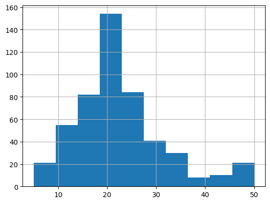

```python
data_set['medv'].hist()
```

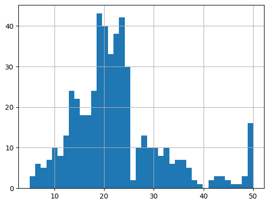

```python
data_set['medv'].hist(bins=40)
```

```
array([<AxesSubplot: title={'center': '0'}>,
       <AxesSubplot: title={'center': '1'}>], dtype=object)
```

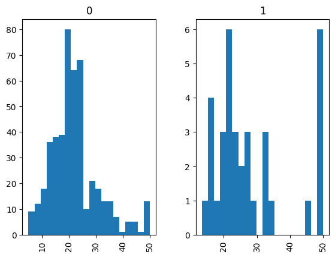

```python
data_set['medv'].hist(bins=20, by=data_set['chas'])
```

```
array([<AxesSubplot: title={'center': '0'}>,
       <AxesSubplot: title={'center': '1'}>], dtype=object)
```

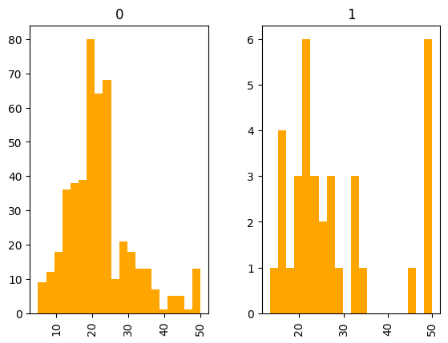

```python
data_set['medv'].hist(bins=20, by=data_set['chas'], color='orange')
```

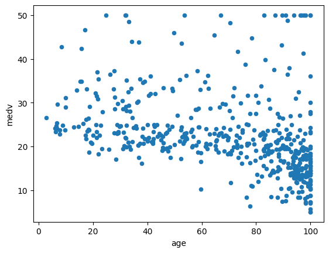

```python
data_set.plot.scatter(x='age', y='medv')
```

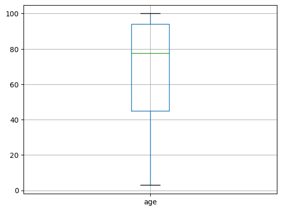

```python
data_set.boxplot('age')
```

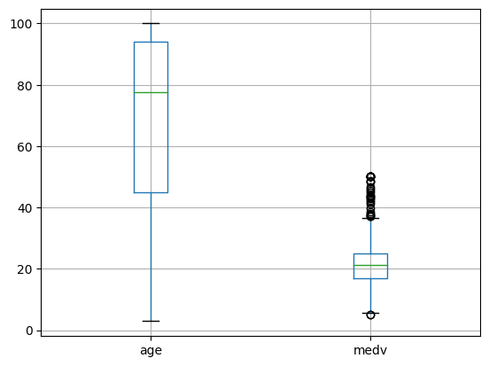

```python
data_set.boxplot(['age', 'medv'])
```

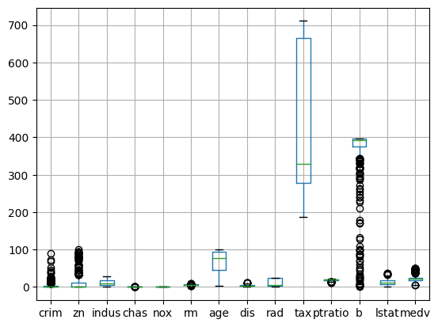

```python
data_set.boxplot()
```

```python
data_set['medv'].mean()
```

```
22.532806324110677
```

```python
data_set['medv'].median()
```

```
21.2
```

```python
data_set.loc[data_set['age'] >= 10, 'medv'].mean()
```

```
22.423529411764708
```

```python
data_set.loc[data_set['age'] < 10, 'medv'].mean()
```

```
26.676923076923078
```

### A highly recommended To Do

- Watch [Complete Python Pandas Data Science Tutorial! (Reading CSV/Excel files, Sorting, Filtering, Groupby)](https://www.youtube.com/watch?v=vmEHCJofslg)
- Watch [Python NumPy Tutorial for Beginners](https://www.youtube.com/watch?v=QUT1VHiLmmI)
- Read chapter [Introduction to NumPy](https://jakevdp.github.io/PythonDataScienceHandbook/02.00-introduction-to-numpy.html) from [Python Data Science Handbook, Jake VanderPlas](https://jakevdp.github.io/PythonDataScienceHandbook/)

DataKolektiv, 2022/23.

hello@datakolektiv.com

[figure not shown]

License: [GPLv3](https://www.gnu.org/licenses/gpl-3.0.txt) This Notebook is free software: you can redistribute it and/or modify it under the terms of the GNU General Public License as published by the Free Software Foundation, either version 3 of the License, or (at your option) any later version. This Notebook is distributed in the hope that it will be useful, but WITHOUT ANY WARRANTY; without even the implied warranty of MERCHANTABILITY or FITNESS FOR A PARTICULAR PURPOSE. See the GNU General Public License for more details. You should have received a copy of the GNU General Public License along with this Notebook. If not, see http://www.gnu.org/licenses/.